# Somerville Happiness Survey Report, Draft 1

Peter Madsen and Chris Salas

2020-11-16

```r
library(tidyverse)
library(openintro)
library(readr)
library(dplyr)
library(forcats)
```

# Introduction

### Research Question

> Describe your research question.
1. How does a person’s gender, age, ethnicity, annual income, housing status, and identity as a student affect their opinion of the cost of housing?
2. How does a person’s gender, age, housing status, and identity as a student affect how safe they feel walking at night?

### Motivation

> Explain what motivated you to investigate this question.

Problems within a community, such as prohibitive housing costs, declining sense of neighborhood safety, or increasing distrust in police, can be obvious and troubling to some groups of people and invisible to others. Additionally, as community problems increase in severity, they can affect some groups first, before spreading to others as the issues worsen. And since these problems are addressed by legislation (which is informed by public opinion), there is a danger that problems which could have been solved quickly and inexpensively at first will become extremely difficult or even impossible to solve by the time everyone is aware.

A pertinent analogy can be drawn from Environmental Science – an “indicator species” is a species which is especially sensitive to environmental contaminants and will show changes in behavior or a decline in population long before other species do, allowing it to serve as a warning sign, or “indicator,” of the health of the ecosystem as a whole. Knowing the indicator species for different environments allows for quick action against pollution events.

Similarly, if something like an “indicator demographic” can be identified for different community problems, this demographic can be used to detect and resolve issues early, before the social health of the entire community is damaged.

### Expectations

> Describe any expectations you started with, concerning what you might learn about your research question.

It is expected that homeowners will be more favorable of housing prices, and it is expected that older people, white people, and wealthy people will be more likely to be homeowners. Conversely, it is expected that younger people, poorer people, and students are more likely to be renters and will be less favorable of house prices.

Regarding the feeling that one’s neighborhood is safe to walk around at night, it is commonly known that men are more likely to feel safe than women. Other demographic trends are hard to easily guess, because the question asks about whether the respondent *feels* safe in their neighborhood at night but does not measure whether they actually *are* or not.

It is expected that both age and annual income will positively correlate with police trust, and that white respondents will be more trusting than non-white respondents.

### Description of Variables

> Indicate what your explanatory and response variables are, and classify them as categorical or quantitative.

Explanatory variables:

- Gender - categorical
- Age - categorical (bins)
- Ethnicity - categorical
- Annual income - categorical (bins)
- Student - categorical (binary)
- Own/rent home? - categorical

Response variables:

- How do you rate the cost of housing? (quantitative)
- How safe do you feel walking at night? (quantitative)
- How would you rate your trust in the local police? (quantitative)

# Data Description

The city of Somerville lies just northwest of Boston and north of Harvard University and the Massachusetts Institute of Technology. In 2011, 2013, 2015, and 2017, residents in Somerville were asked to fill out a survey which, among other topics, asked for respondents to rate their current feeling of happiness, their happiness with their life in general, and with their satisfaction and pride about living in Somerville. This survey has since been called the “Somerville Happiness Survey,” but of interest in this project is the happiness-adjacent questions related to house prices, feeling of safety, and trust in law enforcement. In 2017, there were twenty-seven questions in the survey and 835 responses.

Many of the exact details about the survey are yet to be researched, but a few important details can be inferred from write-in responses to the question on gender, for which many respondents marked both male and female or wrote “multiple people,” suggesting that a single survey was delivered to households rather than one for each household member. This casts some doubt about whether ratings of happiness, anxiety, or neighborhood safety represent an individual or the aggregate rating of several people within a single household.

In this project, the Somerville Happiness Survey responses are analyzed for correlations tangential to happiness after having been filled out for another purpose. With no control groups or applied interventions — varying the explanatory variables here is either impossible or economically unfeasible — this is best understood as an observational study. The observational unit is one individual within a given household, though some responses can be interpreted potentially as household averages, as stated earlier.

Questions on the survey can be considered as belonging to two types, categorical or quantitative, with circled options or a rating scale, respectively. Quantitative questions varied the range and midpoint of the scale, rating from 1 to 10 for some questions and 1 to 5 on others.

# Descriptive Analysis

Analysis can be consider in two sections: first, concerning the trends that were expected to be present; second, trends which were unexpected but significant.

### General Demographics (Figure 1)

Before considering the views of individual subgroups, it is important to understand the broad demographics of Somerville represented in the survey responses.

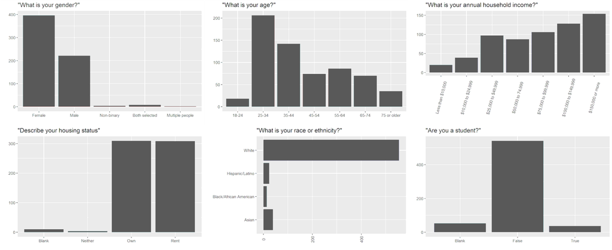

Fig. 1. An overview of Somerville demographics.

From the top left and moving clockwise, it is seen in Figure 1 that the majority of respondents by gender were female (p=0.63), by age were between 25 to 34 years old (p=0.33), by income earned over $150,000 annually (p=0.24), were not students (p=0.86), by ethnicity were white (p=0.88), and were about equally likely to own a home as rent one (each p=0.49, from x=309 and x=308, respectively, and n=631). Considering this, exploring trends relative to race/ethnicity is complicated by a small sample size.

### Concerning Expectations For Cost of Housing (Figures 2 to 4)

As expected, those who own a home are more favorable (2.42±1.18, mean±standard deviation) of the cost of housing than those who rent (2.01±1.08), though both groups rate it poorly (Fig. 2). Trends are less visually clear by annual income (Fig. 3) and age (Fig. 4). Unexpectedly, those who earned less than $10,000, between $10,000 to $24,999, and between $25,000 to $49,999 — the three poorest subgroups — rated housing prices most favorably (2.85±1.69, 2.44±1.37, and 2.29±1.28, respectively).

Only 18 respondents were in the 18-24 age group, and they reported the highest favorability (2.89±1.02), followed by the 65-74 age group (2.73±1.46) and the 75 or older group (2.71±1.36). The expected trend, that increasing age correlates with approval of house prices, is evident from the 35-44 group up to the 65-74 group. Respondents between the age of 35 and 44 were the most disapproving (1.91±0.85).

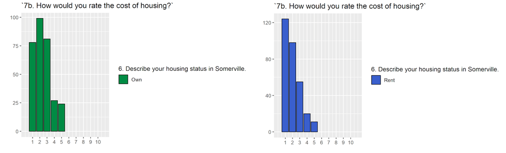

Fig. 2. Favorability of house prices by owners and renters of homes.

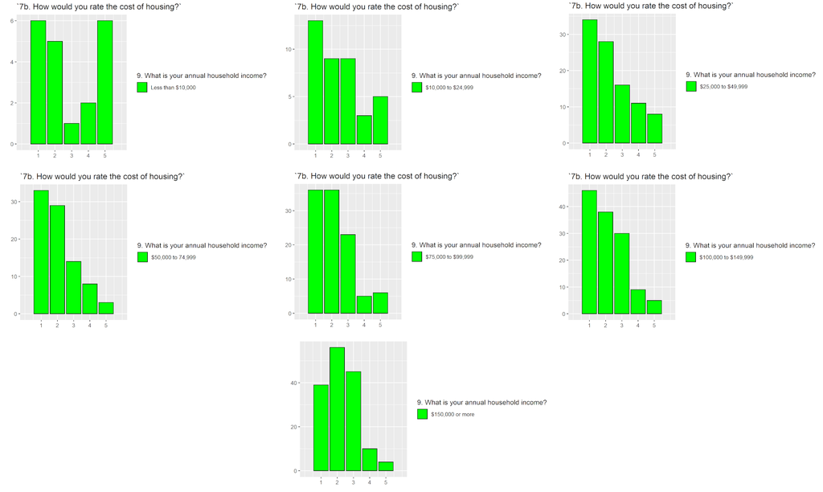

Fig. 3. Favorability of house prices by annual income.

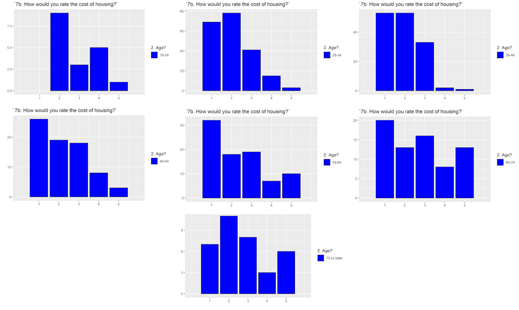

Fig. 4. Favorability of house prices by age group.

### Concerning Expectations For Feeling Safe At Night (Figure 5)

As expected, female respondents ranked their feeling of safety walking in their neighborhood at night lower than male respondents (Fig. 5; 7.87±2.03 for women, compared to 8.39±1.90 for men).

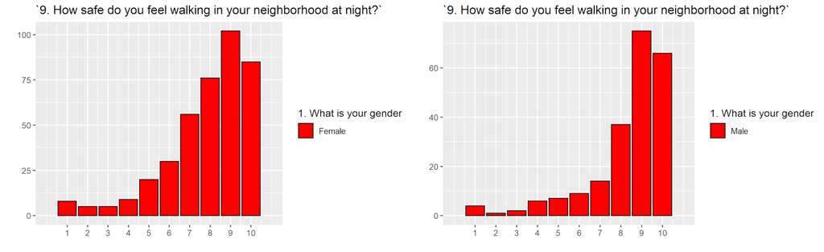

Fig. 5. Feeling of safety walking in neighborhood at night by gender.

### Concerning Expectations For Trust in Local Police (Figures 6 and 7)

Each annual income group has approximately the same mean rating for trust in local police (about 3.7 or 3.8), but the variation in the responses decreases as income increases, beginning at standard deviation 1.27 for those earning less than $10,000 and decreasing to 0.84 for those earning more than $150,000 (Fig. 6). As expected, respondents’ age correlates with trust in the local police (Fig. 7), beginning at 3.60±0.97 for 25-34 year olds and ending at 4.46±0.61 for respondents over 75.

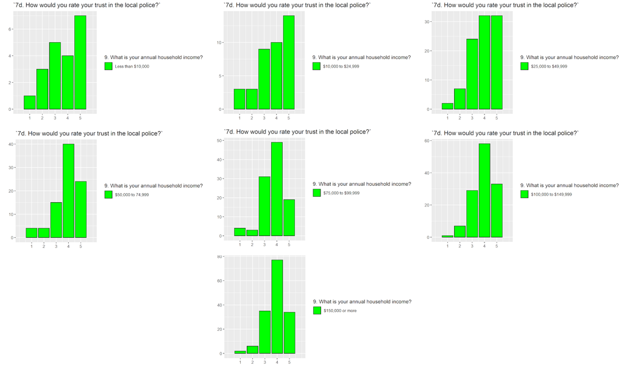

Fig. 6. Trust in local police by annual income.

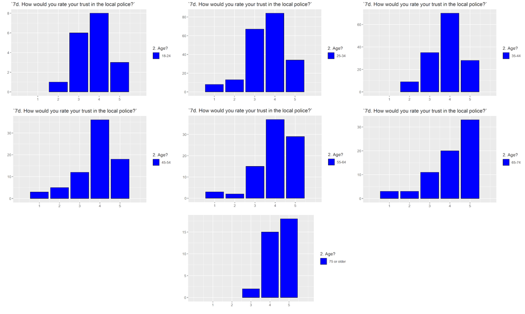

Fig. 7. Trust in local police by age.

### Renting vs. Owning a Home (Figures 8 to 12)

A question worth exploring is whether these trends are simply due to the demographics of renters and homeowners, or whether a respondent’s homeowning status is the better predictor of their views.

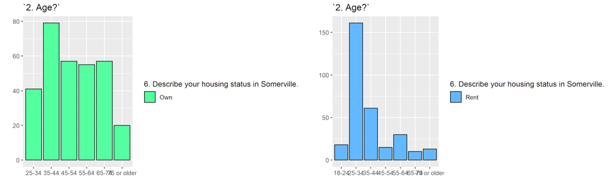

Fig. 8. Distribution of age groups for homeowners and renters.

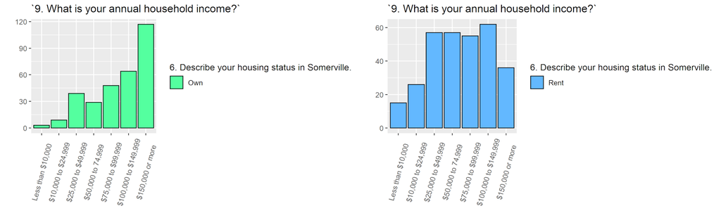

Fig. 9. Distribution of annual income for homeowners and renters.

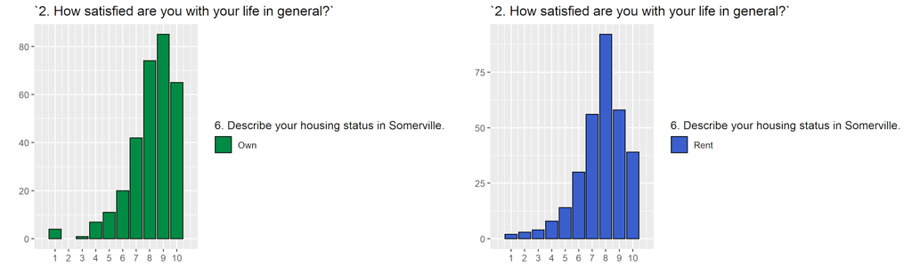

Fig. 10. General life satisfaction for homeowners and renters.

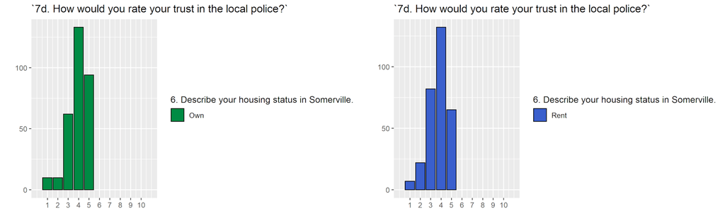

Fig. 11. Trust in police by homeowners and renters.

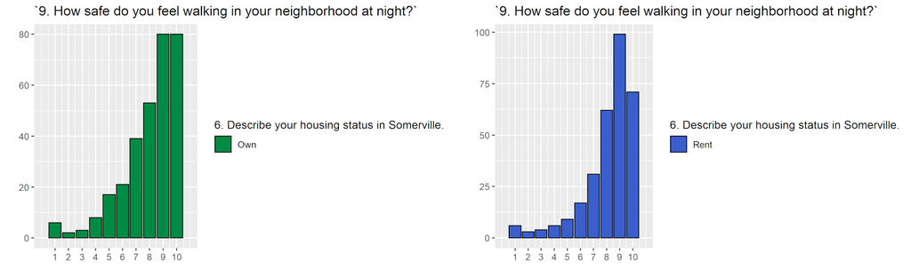

Fig. 12. Feeling of safety walking at night in their neighborhood for homeowners and renters.

```r
# End
```